# ROP NMA Final Analysis

Timothy Disher

# Purpose of the Notebook

The purpose of this document is to house all the necesarry code for analysis including a narrative of interpretations and explanation of any reasons for deviating from protocol. The final script of the analysis is exported as a single r script which will be used for preperation of the final manuscript. Please consider **this document** as the most up to date analysis file. Replication of the final manuscript should take the following form:

1. Execute all script in this notebook.
2. Knit the manuscript markdown document.

Please note that this analysis was undertaken beginning July 4th, 2017 in the summer of my first year in the PhD program at Dalhousie University. As such this served the dual purpose of providing and opportunity to learn approaches to functional programming.

# Data Cleaning

The purpose of this section is to explore the merged data file, identify any potential errors and create a final clean set for analysis.

```r
library(tidyverse)
library(readxl)
library(forcats)
library(broom)
library(stargazer)
library(netmeta)
```

```r
data_arm = read_excel(path = "./data/final_analysis_ROP_data_good_jul4.xlsx", sheet = 1,
                      col_types = )
data_study = read_excel(path = "./data/final_analysis_ROP_data_good_jul4.xlsx", sheet = 2)
head(data_arm)
```

| study.num | study | treatment | trt.group | outcome | actual.timepoint | timepoint.group | mean | std.dev | se | imputed.mean | sample.size | median | iqr.low | iqr.high | range.low | range.high | lower.ci | upper.ci | p.value | num.events | chi.suare.value | average.ga | average.pna | average.pma | imputed.pma | average.bw |
| --- | --- | --- | --- | --- | --- | --- | --- | --- | --- | --- | --- | --- | --- | --- | --- | --- | --- | --- | --- | --- | --- | --- | --- | --- | --- | --- |
| 24 | ÅženerTaplak 2017 | nns.drops | drops.phys | PIPP | 5 min post | recovery | 5.90 | 1.61 | 999 | 999 | 20 | 999 | 999 | 999 | 999 | 999 | 999 | 999 | 999 | 999 | 999 | 888 | 888 | 888 | no | 888 |
| 24 | ÅženerTaplak 2017 | nns.ebm.drops | drops.ebm.mult | PIPP | 5 min post | recovery | 3.20 | 1.36 | 999 | 999 | 20 | 999 | 999 | 999 | 999 | 999 | 999 | 999 | 999 | 999 | 999 | 888 | 888 | 888 | no | 888 |
| 24 | ÅženerTaplak 2017 | sweet.nns.drops | sweet.mult | PIPP | 5 min post | recovery | 3.65 | 1.78 | 999 | 999 | 20 | 999 | 999 | 999 | 999 | 999 | 999 | 999 | 999 | 999 | 999 | 888 | 888 | 888 | no | 888 |
| 24 | ÅženerTaplak 2017 | nns.drops | drops.nns | hr | 5 min post | recovery | 160.50 | 9.40 | 999 | 999 | 20 | 999 | 999 | 999 | 999 | 999 | 999 | 999 | 999 | 999 | 999 | 888 | 888 | 888 | no | 888 |
| 24 | ÅženerTaplak 2017 | nns.ebm.drops | drops.ebm.mult | hr | 5 min post | recovery | 159.70 | 12.86 | 999 | 999 | 20 | 999 | 999 | 999 | 999 | 999 | 999 | 999 | 999 | 999 | 999 | 888 | 888 | 888 | no | 888 |
| 24 | ÅženerTaplak 2017 | sweet.nns.drops | sweet.mult | hr | 5 min post | recovery | 165.70 | 9.99 | 999 | 999 | 20 | 999 | 999 | 999 | 999 | 999 | 999 | 999 | 999 | 999 | 999 | 888 | 888 | 888 | no | 888 |

```r
tail(data_arm)
```

| study.num | study | treatment | trt.group | outcome | actual.timepoint | timepoint.group | mean | std.dev | se | imputed.mean | sample.size | median | iqr.low | iqr.high | range.low | range.high | lower.ci | upper.ci | p.value | num.events | chi.suare.value | average.ga | average.pna | average.pma | imputed.pma | average.bw |
| --- | --- | --- | --- | --- | --- | --- | --- | --- | --- | --- | --- | --- | --- | --- | --- | --- | --- | --- | --- | --- | --- | --- | --- | --- | --- | --- |
| 32 | Zeraati 2015c | drops | drops | face status | during procedure | reactivity | 777.0 | 777.0 | 999 | 999 | 999 | 999 | 999 | 999 | 999 | 999 | 999 | 999 | 999 | 999 | 999 | 30.6 | 34.9 | 35.585714285714289 | yes | 1355.8 |
| 32 | Zeraati 2015c | ss.drops | drops.mult | face status | during procedure | reactivity | 777.0 | 777.0 | 999 | 999 | 999 | 999 | 999 | 999 | 999 | 999 | 999 | 999 | 999 | 999 | 999 | 30.4 | 35.1 | 35.414285714285711 | yes | 1385.8 |
| 23 | Zeraati 2016 | drops | drops | PIPP | 999 | reactivity | 10.0 | 1.7 | 999 | no | 40 | 999 | 999 | 999 | 999 | 999 | 999 | 999 | 999 | 999 | 999 | 30.6 | 34.9 | 35.585714285714289 | yes | 1355.8 |
| 23 | Zeraati 2016 | ss.drops | drops.mult | PIPP | 999 | reactivity | 6.4 | 1.7 | 999 | no | 40 | 999 | 999 | 999 | 999 | 999 | 999 | 999 | 999 | 999 | 999 | 30.4 | 35.1 | 35.414285714285711 | yes | 1385.8 |
| 23 | Zeraati 2016 | drops | drops | PIPP | 999 | recovery | 10.6 | 1.7 | 999 | no | 40 | 999 | 999 | 999 | 999 | 999 | 999 | 999 | 999 | 999 | 999 | 30.6 | 34.9 | 35.585714285714289 | yes | 1355.8 |
| 23 | Zeraati 2016 | ss.drops | drops.mult | PIPP | 999 | recovery | 7.1 | 1.8 | 999 | no | 40 | 999 | 999 | 999 | 999 | 999 | 999 | 999 | 999 | 999 | 999 | 30.4 | 35.1 | 35.414285714285711 | yes | 1385.8 |

```r
head(data_study)
```

| Study.num | study | n | design | pub type | protocol/registry cited | protocol registery foun | connected to another study study | dup code | which studies | control | trt1 | trt2 | trt3 | comparison | ctrl.group | trt1.group2 | trt2.group | trt3.group | comp.by.group | method | speculum | scleral.dep | dose.timing | exam.number | avg.ga | avg.pma | avg.bw | stdy.level.imputed | Containment vs Swaddle | … |
| --- | --- | --- | --- | --- | --- | --- | --- | --- | --- | --- | --- | --- | --- | --- | --- | --- | --- | --- | --- | --- | --- | --- | --- | --- | --- | --- | --- | --- | --- | --- |
| 1 | Boyle 2006 | 40 | Parallel | journal | no | no | no | 0 | 999 | drops | sweet.drops | NNS.drops | sweet.nns.drops | drops vs sweet.drops vs NNS.drops vs sweet.nns.drops | drops | drops.sweet | drops.phys | drops.mult | drops vs drops.sweet vs drops.phys vs drops.mult | BIO | yes | yes | 2min.pre | first only | 888.00000 | 888 | 888.000 | yes | Containment | … |
| 2 | Cogen 2011 | 39 | Parallel | journal | no | no | no | 0 | 999 | no treatment | drops | 999 | 999 | no treatment vs drops vs 999 vs 999 | plac | drops | 999 | 999 | plac vs drops vs 999 vs 999 | BIO | yes | yes | immediately before | not reported | 888.00000 | 888 | 888.000 | no | Containment | … |
| 3 | Costa 2013 | 124 | Parallel | journal | no | no | no | 0 | 999 | drops | sweet.drops | 999 | 999 | drops vs sweet.drops vs 999 vs 999 | drops | drops.sweet | 999 | 999 | drops vs drops.sweet vs 999 vs 999 | BIO | yes | yes | 2min.pre | first only | 888.00000 | 888 | 888.000 | yes | Containment | … |
| 4 | Dhaliwal 2010 | 76 | Crossover | journal | no | yes | no | 0 | 999 | drops | WFDRI.drops | 999 | 999 | drops vs WFDRI.drops vs 999 vs 999 | drops | WFDRI | 999 | 999 | drops vs WFDRI vs 999 vs 999 | WFDRI | yes | no | 2min.pre | any | 888.00000 | 888 | 888.000 | no | Containment | … |
| 5 | Dilli 2014 | 64 | Parallel | journal | no | no | no | 0 | 999 | NNS.drops | sweet.nns.drops | 999 | 999 | NNS.drops vs sweet.nns.drops vs 999 vs 999 | drops.phys | drops.mult | 999 | 999 | drops.phys vs drops.mult vs 999 vs 999 | BIO | yes | unclear | 2min.pre | first only | 888.00000 | 35.4 | 888.000 | no | Containment | … |
| 6 | Gal 2005 | 23 | Crossover | journal | no | no | no | 0 | 999 | drops | sweet.drops | 999 | 999 | drops vs sweet.drops vs 999 vs 999 | drops | drops.sweet | 999 | 999 | drops vs drops.sweet vs 999 vs 999 | BIO | yes | yes | 2min.pre | any | 30.23871 | 35.187096774193549 | 1260.871 | yes | Swaddle | … |

```r
tail(data_study)
```

| Study.num | study | n | design | pub type | protocol/registry cited | protocol registery foun | connected to another study study | dup code | which studies | control | trt1 | trt2 | trt3 | comparison | ctrl.group | trt1.group2 | trt2.group | trt3.group | comp.by.group | method | speculum | scleral.dep | dose.timing | exam.number | avg.ga | avg.pma | avg.bw | stdy.level.imputed | Containment vs Swaddle | … |
| --- | --- | --- | --- | --- | --- | --- | --- | --- | --- | --- | --- | --- | --- | --- | --- | --- | --- | --- | --- | --- | --- | --- | --- | --- | --- | --- | --- | --- | --- | --- |
| 27 | Mehta 2005 | 15 | Crossover | journal | no | no | no | 0 | 999 | drops.bio.spec | drops.bio.nospec | drops.wfdri | 999 | drops.bio.spec vs drops.bio.nospec vs drops.wfdri | drops | drops.nospec | drops.wfdri | 999 | drops vs drops.nospec vs drops.wfdri vs 999 | bio and wfdri | yes for wfdri and control | no | amethocaine if spec used | any | 28.0 | 33,35,36 | 888 | no | 888 | … |
| 28 | Ucar 2014 | 84 | Parallel | poster | no | no | no | 0 | 999 | drops.nns | sweet.Drops | sweet.nns.drops | 999 | drops.nns vs sweet.Drops vs sweet.nns.drops | drops.phys | drops.sweet | drops.mult | 999 | drops.phys vs drops.sweet vs drops.mult vs 999 | 888 | 888 | 888 | 888 | first | 28.7 | 34.200000000000003 | 1280 | no | 888 | … |
| 29 | Xin 0016 | 95 | Parallel | journal | no | no | no | 0 | 999 | drops | drops.sweet | 999 | dropsdrops.sweet | drops vs drops.sweet vs 999 | drops | drops.sweet | 999 | 999 | drops vs drops.sweet vs 999 vs 999 | 888 | 888 | 888 | 888 | 888 | 888.0 | 888 | 888 | 999 | 888 | … |
| 30 | Zeraati 2015a | 80 | Parallel | journal | no | no | yes | 1 | Zeraati 2016,2015a,2015b,2015c | drops | sensorial.saturation | 999 | 999 | drops vs sensorial.saturation vs 999 vs 999 | drops | drops.mult | 999 | 999 | drops vs drops.mult vs 999 vs 999 | 888 | 888 | 888 | 15min.pre | first | 28.0 | NA | 888 | yes | Containment | … |
| 31 | Zeraati 2015b | 80 | Parallel | journal | yes | no | yes | 1 | Zeraati 2016,2015a,2015b,2015c | drops | sensorial.saturation | 999 | 999 | drops vs sensorial.saturation vs 999 vs 999 | drops | drops.mult | 999 | 999 | drops vs drops.mult vs 999 vs 999 | 888 | 888 | 888 | 15min.pre | first | 28.0 | NA | 888 | yes | Containment | … |
| 32 | Zeraati 2015c | 80 | Parallel | journal | no | no | yes | 1 | Zeraati 2016,2015a,2015b,2015c | drops | sensorial.saturation | 999 | 999 | drops vs sensorial.saturation vs 999 vs 999 | drops | drops.mult | 999 | 999 | drops vs drops.mult vs 999 vs 999 | 888 | 888 | 888 | 15min.pre | first | 28.0 | NA | 888 | yes | Containment | … |

```r
summary(data_arm)
```

```
   study.num        study            treatment          trt.group           outcome          actual.timepoint   timepoint.group
 Min.   : 1.00   Length:245         Length:245         Length:245         Length:245         Length:245         Length:245
 1st Qu.: 8.00   Class :character   Class :character   Class :character   Class :character   Class :character   Class :character
 Median :16.00   Mode  :character   Mode  :character   Mode  :character   Mode  :character   Mode  :character   Mode  :character
 Mean   :16.75
 3rd Qu.:27.00
 Max.   :32.00
      mean          std.dev            se        imputed.mean        sample.size         median         iqr.low         iqr.high
 Min.   :  0.8   Min.   :  0.6   Min.   :  0.4   Length:245         Min.   :  5.00   Min.   : -7.0   Min.   :  4.0   Min.   :  9.2
 1st Qu.: 12.2   1st Qu.:  3.5   1st Qu.:999.0   Class :character   1st Qu.: 15.00   1st Qu.:888.0   1st Qu.:999.0   1st Qu.:999.0
 Median :112.5   Median :888.0   Median :999.0   Mode  :character   Median : 20.00   Median :999.0   Median :999.0   Median :999.0
 Mean   :466.7   Mean   :545.3   Mean   :940.3                      Mean   : 41.42   Mean   :756.9   Mean   :982.8   Mean   :982.9
 3rd Qu.:999.0   3rd Qu.:999.0   3rd Qu.:999.0                      3rd Qu.: 32.00   3rd Qu.:999.0   3rd Qu.:999.0   3rd Qu.:999.0
 Max.   :999.0   Max.   :999.0   Max.   :999.0                      Max.   :999.00   Max.   :999.0   Max.   :999.0   Max.   :999.0
   range.low       range.high     lower.ci        upper.ci       p.value            num.events    chi.suare.value    average.ga
 Min.   :  0.0   Min.   :  8   Min.   :  7.3   Min.   :  9.3   Length:245         Min.   :  0.0   Min.   :  2.59   Min.   : 26.4
 1st Qu.:999.0   1st Qu.:999   1st Qu.:999.0   1st Qu.:999.0   Class :character   1st Qu.:999.0   1st Qu.:999.00   1st Qu.: 28.0
 Median :999.0   Median :999   Median :999.0   Median :999.0   Mode  :character   Median :999.0   Median :999.00   Median : 28.3
 Mean   :967.3   Mean   :968   Mean   :990.9   Mean   :990.9                      Mean   :820.9   Mean   :990.87   Mean   :201.2
 3rd Qu.:999.0   3rd Qu.:999   3rd Qu.:999.0   3rd Qu.:999.0                      3rd Qu.:999.0   3rd Qu.:999.00   3rd Qu.: 30.5
 Max.   :999.0   Max.   :999   Max.   :999.0   Max.   :999.0                      Max.   :999.0   Max.   :999.00   Max.   :999.0
  average.pna    average.pma        imputed.pma         average.bw
 Min.   : 16.2   Length:245         Length:245         Length:245
 1st Qu.: 50.8   Class :character   Class :character   Class :character
 Median :888.0   Mode  :character   Mode  :character   Mode  :character
 Mean   :671.6
 3rd Qu.:888.0
 Max.   :999.0
```

```r
summary(data_study)
```

```
   Study.num        study                 n             design            pub type         protocol/registry cited protocol registery foun
 Min.   : 1.00   Length:32          Min.   : 15.00   Length:32          Length:32          Length:32               Length:32
 1st Qu.: 8.75   Class :character   1st Qu.: 31.50   Class :character   Class :character   Class :character        Class :character
 Median :16.50   Mode  :character   Median : 40.00   Mode  :character   Mode  :character   Mode  :character        Mode  :character
 Mean   :16.50                      Mean   : 54.56
 3rd Qu.:24.25                      3rd Qu.: 80.00
 Max.   :32.00                      Max.   :124.00
 connected to another study study    dup code       which studies        control              trt1               trt2
 Length:32                        Min.   :0.00000   Length:32          Length:32          Length:32          Length:32
 Class :character                 1st Qu.:0.00000   Class :character   Class :character   Class :character   Class :character
 Mode  :character                 Median :0.00000   Mode  :character   Mode  :character   Mode  :character   Mode  :character
                                  Mean   :0.09375
                                  3rd Qu.:0.00000
                                  Max.   :1.00000
     trt3            comparison         ctrl.group        trt1.group2         trt2.group         trt3.group        comp.by.group
 Length:32          Length:32          Length:32          Length:32          Length:32          Length:32          Length:32
 Class :character   Class :character   Class :character   Class :character   Class :character   Class :character   Class :character
 Mode  :character   Mode  :character   Mode  :character   Mode  :character   Mode  :character   Mode  :character   Mode  :character



    method            speculum         scleral.dep        dose.timing        exam.number            avg.ga        avg.pma
 Length:32          Length:32          Length:32          Length:32          Length:32          Min.   : 26.4   Length:32
 Class :character   Class :character   Class :character   Class :character   Class :character   1st Qu.: 28.0   Class :character
 Mode  :character   Mode  :character   Mode  :character   Mode  :character   Mode  :character   Median : 28.6   Mode  :character
                                                                                                Mean   :324.2
                                                                                                3rd Qu.:888.0
                                                                                                Max.   :888.0
     avg.bw     stdy.level.imputed Containment vs Swaddle Overall risk of bias objective Overall risk of bias subjective Sequence Generation
 Min.   : 888   Length:32          Length:32              Length:32                      Length:32                       Length:32
 1st Qu.: 888   Class :character   Class :character       Class :character               Class :character                Class :character
 Median : 888   Mode  :character   Mode  :character       Mode  :character               Mode  :character                Mode  :character
 Mean   :1027
 3rd Qu.:1028
 Max.   :1880
 Allocation concealment Blinding personnel Blinding outcomes objective Blinding subjective outcomes Incomplete outcome    ev_io
 Length:32              Length:32          Length:32                   Length:32                    Length:32          Length:32
 Class :character       Class :character   Class :character            Class :character             Class :character   Class :character
 Mode  :character       Mode  :character   Mode  :character            Mode  :character             Mode  :character   Mode  :character



 Selective reporting    ev_sr              other           pipp.rescale          notes
 Length:32           Length:32          Length:32          Length:32          Length:32
 Class :character    Class :character   Class :character   Class :character   Class :character
 Mode  :character    Mode  :character   Mode  :character   Mode  :character   Mode  :character
```

Everything appears to have been imported correctly. Some changes that will make things a little easier may be to make treatment, trt.group, outcome, actual.timepoint, and timepoint.group into factors.

```r
data_arm[,2:7] = map(data_arm[,2:7],as_factor) ## runs along columns 2:7 and applies as_factor
data_study[,-c(1,3,9,26:28)] = map(data_study[,-c(1,3,9,26:28)],as_factor)
summary(data_arm,maxsum = 50) ### identifying slight mispellings
```

```
   study.num                   study                treatment           trt.group                            outcome
 Min.   : 1.00   ÅženerTaplak 2017:18   nns.drops        :36   drops.phys    :28   PIPP                          :83
 1st Qu.: 8.00   Benzer 2015      : 3   nns.ebm.drops    : 6   drops.ebm.mult: 8   hr                            :10
 Median :16.00   Boyle 2006       : 4   sweet.nns.drops  :36   sweet.mult    : 6   O2 sat                        :12
 Mean   :16.75   Cogen 2011       : 2   plac             : 6   drops.nns     : 8   NIPS                          : 2
 3rd Qu.:27.00   Costa 2013       : 6   sweet.rep        : 1   plac          : 8   NIPS >= 4                     : 2
 Max.   :32.00   Dhaliwal 2010    : 6   sweet.sing       : 1   sweet.rep     : 1   min02                         : 2
                 Dilli 2014       :12   drops            :68   sweet.sing    : 1   maxHR                         : 2
                 Gal 2005         :14   sweet.drops      :24   drops         :68   02 desat <85%                 : 2
                 Grabska 2005     :12   wfdri.drops      :19   drops.sweet   :24   tachy >180bpm                 : 4
                 Ilarslan 2012    : 6   paracetamol.drops: 8   drops.mult    :38   brady < 100bpm                : 4
                 Kabatas 2016     :10   NIDCAP           : 3   drops.wfdri   :19   crying time                   :12
                 Kleberg 2008     : 6   NO.sweet.drops   : 3   drops.tyl     : 8   any.ae                        :10
                 Mandel 2012      : 6   morphine.drops   : 1   drops.NO.sweet: 3   02 desat > 10%                : 6
                 Manjunatha 2009  : 3   no.treatment     : 2   drops.morph   : 1   RR                            : 6
                 Marsh 2005       :10   nospec.drops     :16   drops.nospec  :16   02 desat                      : 2
                 Mehta 2005       :48   nns              : 4   phys          : 4   brady and desat               : 2
                 Mehta 2010       : 8   sweet            : 2   sweet         : 2   02 sat                        : 4
                 Mitchell 2004    : 6   EBM.drops        : 2   diet1hr       : 1   Apnea in 24h                  : 2
                 Nesargi 2015     : 4   feed.1hr.drops   : 1   diet2hr       : 1   02 < 88% in 24h               : 2
                 Olsson 2011      : 8   feed.2hr.drops   : 1                       02 desat >10% on PIPP points  : 4
                 O'sullivan 2010  :12   ss.drops         : 5                       bp change                     : 6
                 Rosali 2015      : 4                                              hr change                     : 6
                 Rush 2005        : 8                                              02 sat change                 : 6
                 Saunders 1993    : 2                                              any brow bulge                : 6
                 Seifi 2013       : 6                                              any eye squeeze               : 6
                 Strube 2010      : 2                                              any nlf                       : 6
                 Ucar 2014        : 3                                              any mouth open                : 6
                 Xin 0016         : 6                                              any cry                       : 6
                 Zeraati 2015a    : 2                                              PIPP <7                       : 2
                 Zeraati 2015b    : 2                                              PIPP 7-12                     : 2
                 Zeraati 2015c    : 2                                              PIPP >= 12                    : 2
                 Zeraati 2016     : 4                                              HR increase                   : 2
                                                                                   02 decrease                   : 2
                                                                                   N-PASS                        : 2
                                                                                   desat < 80%                   : 2
                                                                                   adverse event (brady or desat): 2
                                                                                   cry factor                    : 2
                           actual.timepoint   timepoint.group      mean          std.dev            se        imputed.mean
 5 min post                        :14      recovery  : 93    Min.   :  0.8   Min.   :  0.6   Min.   :  0.4   Length:245
```

[output cut: 98 more lines]

[output not shown]

```r
summary(data_study,maxum= 50)
```

```
   Study.num               study          n                design      pub type  protocol/registry cited protocol registery foun
 Min.   : 1.00   Boyle 2006   : 1   Min.   : 15.00   Parallel :26   journal:29   no :29                  no :26
 1st Qu.: 8.75   Cogen 2011   : 1   1st Qu.: 31.50   Crossover: 6   poster : 3   yes: 3                  yes: 6
 Median :16.50   Costa 2013   : 1   Median : 40.00
 Mean   :16.50   Dhaliwal 2010: 1   Mean   : 54.56
 3rd Qu.:24.25   Dilli 2014   : 1   3rd Qu.: 80.00
 Max.   :32.00   Gal 2005     : 1   Max.   :124.00
                 (Other)      :26
 connected to another study study    dup code                              which studies         control                     trt1
 no :28                           Min.   :0.00000   999                           :28    drops       :17   sweet.drops         : 5
 yes: 4                           1st Qu.:0.00000   Zeraati 2016,2015a,2015b,2015c: 4    nns.drops   : 4   sweet.nns.drops     : 5
                                  Median :0.00000                                        no treatment: 2   sensorial.saturation: 4
                                  Mean   :0.09375                                        NNS.drops   : 2   drops               : 3
                                  3rd Qu.:0.00000                                        sweet.drops : 1   WFDRI.drops         : 1
                                  Max.   :1.00000                                        no.treatment: 1   paracetamol.drops   : 1
                                                                                         (Other)     : 5   (Other)             :13
                trt2                          trt3                                                   comparison       ctrl.group
 NNS.drops        : 1   sweet.nns.drops         : 1   drops vs sensorial.saturation vs 999 vs 999         : 4   drops      :19
 999              :25   999                     :29   drops vs sweet.drops vs 999 vs 999                  : 3   plac       : 4
 paracetamol.drops: 2   nns.dropsnns.drops.sweet: 1   no treatment vs drops vs 999 vs 999                 : 2   drops.phys : 6
 nns.sweet.drops  : 1   dropsdrops.sweet        : 1   NNS.drops vs sweet.nns.drops vs 999 vs 999          : 2   drops.sweet: 1
 sweet.single     : 1                                 nns.drops vs sweet.nns.drops vs 999 vs 999          : 2   phys       : 1
 drops.wfdri      : 1                                 drops vs sweet.drops vs NNS.drops vs sweet.nns.drops: 1   1hr.feed   : 1
 sweet.nns.drops  : 1                                 (Other)                                             :18
            trt1.group2             trt2.group      trt3.group                                          comp.by.group           method
 drops.mult       :11   drops.phys       : 1   drops.mult: 1   drops vs drops.mult vs 999 vs 999               : 6    BIO          :21
 drops.sweet      : 7   999              :25   999       :30   drops.phys vs drops.mult vs 999 vs 999          : 5    WFDRI        : 1
 drops            : 4   drops.paracetamol: 2   sweet.mult: 1   drops vs drops.sweet vs 999 vs 999              : 4    BIO or WFDRI : 1
 WFDRI            : 1   drops.ebm.mult   : 1                   plac vs drops vs 999 vs 999                     : 3    888          : 8
 drops.paracetamol: 1   sweet.single     : 1                   drops vs drops.sweet vs drops.phys vs drops.mult: 1    bio and wfdri: 1
 drops.sweet.NO2  : 1   drops.wfdri      : 1                   drops vs WFDRI vs 999 vs 999                    : 1
 (Other)          : 7   drops.mult       : 1                   (Other)                                         :12
                      speculum         scleral.dep             dose.timing       exam.number     avg.ga        avg.pma              avg.bw
 yes                      :22   yes          :16   2min.pre          :12   any         :10   Min.   : 26.4   Length:32          Min.   : 888
 no                       : 1   no           : 2   15min.pre         : 4   first       : 7   1st Qu.: 28.0   Class :character   1st Qu.: 888
 unclear                  : 1   unclear      : 5   1min.pre          : 3   888         : 6   Median : 28.6   Mode  :character   Median : 888
 888                      : 7   yes in London: 1   888               : 3   first only  : 4   Mean   :324.2                      Mean   :1027
 yes for wfdri and control: 1   888          : 8   immediately before: 2   unclear     : 2   3rd Qu.:888.0                      3rd Qu.:1028
                                                   60min.pre         : 2   not reported: 1   Max.   :888.0                      Max.   :1880
                                                   (Other)           : 6   (Other)     : 2
```

[output cut: 25 more lines]

```
 low    :25          999                                                                                  :31   low :29   no :30
 unclear: 1          all results reported as an index, which is essentially a pooled change from baseline.: 1   high: 3   yes: 2
 high   : 6




                                                              notes
 999                                                             :16
 contrast data?                                                  : 4
 NNS is not able to be blinded                                   : 1
 Other is high because it is unclear how they handled paired data: 1
 No discussion of washout effect                                 : 1
 all outcomes reported across multiple publications              : 1
 (Other)                                                         : 8
```

# Sweet.rep to sweet, and fix trt groups

```r
data_arm %>% filter(trt.group == "sweet.rep")
```

| study.num | study | treatment | trt.group | outcome | actual.timepoint | timepoint.group | mean | std.dev | se | imputed.mean | sample.size | median | iqr.low | iqr.high | range.low | range.high | lower.ci | upper.ci | p.value | num.events | chi.suare.value | average.ga | average.pna | average.pma | imputed.pma | average.bw |
| --- | --- | --- | --- | --- | --- | --- | --- | --- | --- | --- | --- | --- | --- | --- | --- | --- | --- | --- | --- | --- | --- | --- | --- | --- | --- | --- |
| 25 | Benzer 2015 | sweet.rep | sweet.rep | PIPP | first eye 30 sec | reactivity | 7 | 2.5 | 999 | 999 | 22 | 999 | 999 | 999 | 999 | 999 | 999 | 999 | 999 | 999 | 999 | 888 | 888 | 888 | no | 888 |

```r
data_arm = data_arm %>% mutate(trt.group = replace(trt.group, trt.group == "drops.nns","drops.phys"),
                               treatment = replace(treatment, treatment == "sweet.rep","sweet"))
data_arm = data_arm %>% mutate(trt.group = replace(trt.group, trt.group == "sweet.rep","sweet"))
```

# Outcome summaries

## All Studies - high level for inclusion after prisma

```r
lump %>% arrange(trt.group) %>% mutate(treatment = as.character(treatment),
                                       trt.group = as.character(trt.group)) %>%rename("Treatment" = treatment,
                                       "Treatment Group "= trt.group) %>%
  stargazer(summary = FALSE, out = "figs/lump_split.html", rownames = FALSE)
```

```
% Table created by stargazer v.5.2 by Marek Hlavac, Harvard University. E-mail: hlavac at fas.harvard.edu
% Date and time: Mon, Jul 10, 2017 - 10:41:45 AM
\begin{table}[!htbp] \centering
  \caption{}
  \label{}
\begin{tabular}{@{\extracolsep{5pt}} cc}
\\[-1.8ex]\hline
\hline \\[-1.8ex]
Treatment & Treatment Group  \\
\hline \\[-1.8ex]
drops & drops \\
nns.drops & drops.phys \\
nns.ebm.drops & drops.ebm.mult \\
EBM.drops & drops.ebm.mult \\
sweet.nns.drops & sweet.mult \\
plac & plac \\
no.treatment & plac \\
sweet.sing & sweet.sing \\
sweet.drops & drops.sweet \\
sweet.nns.drops & drops.mult \\
NIDCAP & drops.mult \\
ss.drops & drops.mult \\
wfdri.drops & drops.wfdri \\
paracetamol.drops & drops.tyl \\
NO.sweet.drops & drops.NO.sweet \\
morphine.drops & drops.morph \\
nospec.drops & drops.nospec \\
nns & phys \\
sweet & sweet \\
feed.1hr.drops & diet1hr \\
feed.2hr.drops & diet2hr \\
\hline \\[-1.8ex]
\end{tabular}
\end{table}
```

## Primary outcome: Validated Pain Assessment Tool - Reactivity

```r
semi_join(data_study, pa_recov %>% distinct(study))
```

```
Column `study` joining factors with different levels, coercing to character vector
```

| Study.num | study | n | design | pub type | protocol/registry cited | protocol registery foun | connected to another study study | dup code | which studies | control | trt1 | trt2 | trt3 | comparison | ctrl.group | trt1.group2 | trt2.group | trt3.group | comp.by.group | method | speculum | scleral.dep | dose.timing | exam.number | avg.ga | avg.pma | avg.bw | stdy.level.imputed | Containment vs Swaddle | … |
| --- | --- | --- | --- | --- | --- | --- | --- | --- | --- | --- | --- | --- | --- | --- | --- | --- | --- | --- | --- | --- | --- | --- | --- | --- | --- | --- | --- | --- | --- | --- |
| 24 | ÅženerTaplak 2017 | 60 | Parallel | journal | no | no | no | 0 | 999 | nns.drops | nns.ebm.drops | nns.sweet.drops | 999 | nns.drops vs nns.ebm.drops vs nns.sweet.drops | drops | drops | drops.ebm.mult | sweet.mult | drops vs drops vs drops.ebm.mult vs sweet.mult | BIO | yes | yes | 1min.pre | 888 | 888.00000 | 888 | 888.000 | 999 | Containment | … |
| 3 | Costa 2013 | 124 | Parallel | journal | no | no | no | 0 | 999 | drops | sweet.drops | 999 | 999 | drops vs sweet.drops vs 999 vs 999 | drops | drops.sweet | 999 | 999 | drops vs drops.sweet vs 999 vs 999 | BIO | yes | yes | 2min.pre | first only | 888.00000 | 888 | 888.000 | yes | Containment | … |
| 6 | Gal 2005 | 23 | Crossover | journal | no | no | no | 0 | 999 | drops | sweet.drops | 999 | 999 | drops vs sweet.drops vs 999 vs 999 | drops | drops.sweet | 999 | 999 | drops vs drops.sweet vs 999 vs 999 | BIO | yes | yes | 2min.pre | any | 30.23871 | 35.187096774193549 | 1260.871 | yes | Swaddle | … |
| 7 | Grabska 2005 | 32 | Parallel | journal | no | no | no | 0 | 999 | NNS.drops | sweet.nns.drops | 999 | 999 | NNS.drops vs sweet.nns.drops vs 999 vs 999 | drops.phys | drops.mult | 999 | 999 | drops.phys vs drops.mult vs 999 vs 999 | BIO | yes | yes | 2min.pre | unclear | 28.50000 | 35.450000000000003 | 1304.000 | yes | Swaddle | … |
| 21 | Manjunatha 2009 | 18 | Parallel | journal | no | no | no | 0 | 999 | drops | morphine.drops | paracetamol.drops | 999 | drops vs morphine.drops vs paracetamol.drops vs 999 | drops | drops.morphine | drops.paracetamol | 999 | drops vs drops.morphine vs drops.paracetamol vs 999 | BIO | yes | yes | 60min.pre | 888 | 42.00000 | NA | 1332.000 | no | Containment | … |
| 11 | Marsh 2005 | 22 | Crossover | journal | no | no | no | 0 | 999 | no.treatment | drops | 999 | 999 | no.treatment vs drops vs 999 vs 999 | plac | drops | 999 | 999 | plac vs drops vs 999 vs 999 | BIO | yes | yes | immediately before | any | 888.00000 | 888 | 888.000 | yes | Containment | … |
| 12 | Mehta 2010 | 40 | Crossover | journal | no | no | no | 0 | 999 | nns | NNS.drops | 999 | 999 | nns vs NNS.drops vs 999 vs 999 | phys | drops.phys | 999 | 999 | phys vs drops.phys vs 999 vs 999 | BIO | yes | yes | NA | any | 29.00000 | 33.3 first; 35.3 second | 1037.772 | no | Swaddle | … |
| 13 | Mitchell 2004 | 30 | Parallel | journal | no | no | no | 0 | 999 | nns.drops | sweet.nns.drops | 999 | 999 | nns.drops vs sweet.nns.drops vs 999 vs 999 | drops.phys | drops.mult | 999 | 999 | drops.phys vs drops.mult vs 999 vs 999 | BIO | yes | yes | repeated 1 min | any | 26.90000 | 888 | 976.000 | yes | Swaddle | … |
| 14 | Nesargi 2015 | 20 | Parallel | journal | no | no | no | 0 | 999 | drops | sweet | 999 | 999 | drops vs sweet vs 999 vs 999 | drops | sweet | 999 | 999 | drops vs sweet vs 999 vs 999 | BIO | yes | yes | 2min.pre | first but compared against second without treatment | 27.93500 | 35.179999999999993 | 1025.360 | yes | Containment | … |
| 17 | Rosali 2015 | 40 | Parallel | journal | no | no | no | 0 | 999 | drops | ebm.drops | 999 | 999 | drops vs ebm.drops vs 999 vs 999 | drops | drops.ebm.mult | 999 | 999 | drops vs drops.ebm.mult vs 999 vs 999 | BIO | yes | yes | 2min.pre | unclear | 28.00000 | NA | 888.000 | yes | Swaddle | … |

[output cut: 2 more lines]

### Assessing missing means - Symmetry in medians?

```r
pa_reac %>% filter(mean == 888) %>% mutate(mean_imp = )
```

| study.num | study | treatment | trt.group | outcome | actual.timepoint | timepoint.group | mean | std.dev | se | imputed.mean | sample.size | median | iqr.low | iqr.high | range.low | range.high | lower.ci | upper.ci | p.value | num.events | chi.suare.value | average.ga | average.pna | average.pma | imputed.pma | average.bw |
| --- | --- | --- | --- | --- | --- | --- | --- | --- | --- | --- | --- | --- | --- | --- | --- | --- | --- | --- | --- | --- | --- | --- | --- | --- | --- | --- |
| 8 | Kabatas 2016 | paracetamol.drops | drops.tyl | PIPP | during | reactivity | 888 | 888 | 999 | yes | 58 | 12.0 | 9 | 13.0 | 999 | 999 | 999 | 999 | 999 | 999 | 999 | 28.0 | 999 | 32.299999999999997 | no | 1092 |
| 8 | Kabatas 2016 | drops | drops | PIPP | during | reactivity | 888 | 888 | 999 | yes | 56 | 14.0 | 13 | 15.0 | 999 | 999 | 999 | 999 | 999 | 999 | 999 | 28.3 | 999 | 32.5 | no | 1170 |
| 9 | Kleberg 2008 | NIDCAP | drops.mult | PIPP | during | reactivity | 888 | 888 | 999 | yes | 33 | 13.0 | 999 | 999.0 | 2 | 18 | 999 | 999 | 0.683*mann-whitney U | 999 | 999 | 888.0 | 888 | 888 | 888 | NA |
| 9 | Kleberg 2008 | drops | drops | PIPP | during | reactivity | 888 | 888 | 999 | yes | 35 | 13.5 | 999 | 999.0 | 0 | 16 | 999 | 999 | 0.68300000000000005 | 999 | 999 | 888.0 | 888 | 888 | 888 | NA |
| 15 | Olsson 2011 | sweet.drops | drops.sweet | PIPP | during | reactivity | 888 | 888 | 999 | yes | 14 | 8.0 | 5 | 9.2 | 999 | 999 | 999 | 999 | 999 | 999 | 999 | 28.9 | 888 | 888 | no | 1202 |
| 15 | Olsson 2011 | drops | drops | PIPP | during | reactivity | 888 | 888 | 999 | yes | 15 | 6.0 | 4 | 9.2 | 999 | 999 | 999 | 999 | 999 | 999 | 999 | 27.9 | 888 | 888 | no | 1051 |
| 16 | O'sullivan 2010 | nns.drops | drops.phys | PIPP | during | reactivity | 888 | 888 | 999 | yes | 20 | 888.0 | 999 | 999.0 | 888 | 888 | 999 | 999 | 999 | 999 | 999 | 29.5 | 999 | 33.1 | no | 1140 |
| 16 | O'sullivan 2010 | sweet.nns.drops | drops.mult | PIPP | during | reactivity | 888 | 888 | 999 | yes | 20 | 888.0 | 999 | 999.0 | 888 | 888 | 999 | 999 | 999 | 999 | 999 | 29.8 | 999 | 33 | no | 1139 |

```r
pa_reac = pa_reac %>% mutate(mean_imp = ifelse(mean == 888, median,mean)) # creates a new variable where missing means are imputed from medians
pa_reac = data_study %>% select(study,speculum,scleral.dep,`Containment vs Swaddle`) %>% right_join(pa_reac, by = "study") # bring study level data over
```

```
Column `study` joining factors with different levels, coercing to character vector
```

```r
pa_reac %>% select(median, range.low, range.high,iqr.low,iqr.high) %>% filter(median < 999, range.low < 999) %>% mutate(low_dist = median - range.low,
                  high_dist = range.high - median)
```

| median | range.low | range.high | iqr.low | iqr.high | low_dist | high_dist |
| --- | --- | --- | --- | --- | --- | --- |
| 13.0 | 2 | 18 | 999 | 999 | 11.0 | 5.0 |
| 13.5 | 0 | 16 | 999 | 999 | 13.5 | 2.5 |
| 888.0 | 888 | 888 | 999 | 999 | 0.0 | 0.0 |
| 888.0 | 888 | 888 | 999 | 999 | 0.0 | 0.0 |

### Placebo response graphs

```
'.\figs\primary outcome\pain scales reactivity' already exists
```

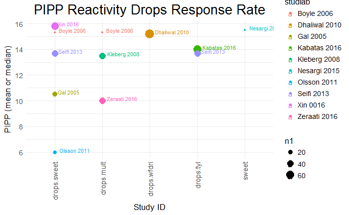

```r
plac_resp_graph(data = pa_reac_contrast, ref = "drops",filter = "treat1",facet = FALSE, location = pa_reac_loc,
               x = "treat2", y = "mean1", type = "scat", fill = "studlab", size = "n1", outcome = "pa_reac")
```

### Table of Study Characterstics

```r
data_study_table = data_study
data_study_table[data_study == 888 | data_study == 999] <- NA
pa_reac_study_char = data_study_table %>% select(study,n,design,ctrl.group,trt1.group2,trt2.group,trt3.group,method,speculum,scleral.dep,avg.pma,`Containment vs Swaddle`) %>% semi_join((pa_reac %>% select(study) %>% distinct()),by = "study") %>% mutate(avg.pma = round(as.numeric(avg.pma),2))
```

```
Column `study` joining factor and character vector, coercing into character vector
```

```r
pa_reac_study_char[,c(1,3:10,12)] = map(pa_reac_study_char[,c(1,3:10,12)],as.character)
stargazer(pa_reac_study_char, out = "./figs/primary outcome/pain scales reactivity/pa_reac_study_char.html",summary = FALSE, rownames = FALSE)
```

```
% Table created by stargazer v.5.2 by Marek Hlavac, Harvard University. E-mail: hlavac at fas.harvard.edu
% Date and time: Mon, Jul 10, 2017 - 8:44:15 AM
\begin{table}[!htbp] \centering
  \caption{}
  \label{}
\begin{tabular}{@{\extracolsep{5pt}} cccccccccccc}
\\[-1.8ex]\hline
\hline \\[-1.8ex]
study & n & design & ctrl.group & trt1.group2 & trt2.group & trt3.group & method & speculum & scleral.dep & avg.pma & Containment vs Swaddle \\
\hline \\[-1.8ex]
ÅženerTaplak 2017 & 60 & Parallel & drops & drops & drops.ebm.mult & sweet.mult & BIO & yes & yes & NA & Containment \\
Benzer 2015 & 64 & Parallel & plac & sweet.rep & sweet.single &  &  &  &  & NA &  \\
Boyle 2006 & 40 & Parallel & drops & drops.sweet & drops.phys & drops.mult & BIO & yes & yes & NA & Containment \\
Cogen 2011 & 39 & Parallel & plac & drops &  &  & BIO & yes & yes & NA & Containment \\
Dhaliwal 2010 & 76 & Crossover & drops & WFDRI &  &  & WFDRI & yes & no & NA & Containment \\
Dilli 2014 & 64 & Parallel & drops.phys & drops.mult &  &  & BIO & yes & unclear & 35.4 & Containment \\
Gal 2005 & 23 & Crossover & drops & drops.sweet &  &  & BIO & yes & yes & 35.19 & Swaddle \\
Grabska 2005 & 32 & Parallel & drops.phys & drops.mult &  &  & BIO & yes & yes & 35.45 & Swaddle \\
Ilarslan 2012 & 40 & Parallel & drops.phys & drops.mult &  &  &  & yes &  & NA &  \\
Kabatas 2016 & 114 & Parallel & drops & drops.paracetamol &  &  & BIO & yes & unclear & 33.26 & Containment \\
Kleberg 2008 & 36 & Crossover & drops & drops.mult &  &  & BIO or WFDRI & yes & yes in London & 35.26 & Containment \\
Mandel 2012 & 41 & Parallel & drops.sweet & drops.sweet.NO2 &  &  & BIO & yes & yes & 35.26 & Swaddle \\
Marsh 2005 & 22 & Crossover & plac & drops &  &  & BIO & yes & yes & NA & Containment \\
Mitchell 2004 & 30 & Parallel & drops.phys & drops.mult &  &  & BIO & yes & yes & NA & Swaddle \\
Nesargi 2015 & 20 & Parallel & drops & sweet &  &  & BIO & yes & yes & 35.18 & Containment \\
Olsson 2011 & 30 & Parallel & drops & drops.sweet &  &  & BIO & no & unclear & NA & Containment \\
O'sullivan 2010 & 40 & Parallel & drops.phys & drops.mult &  &  & BIO & yes & yes & 33 & Swaddle \\
Rosali 2015 & 40 & Parallel & drops & drops.ebm.mult &  &  & BIO & yes & yes & NA & Swaddle \\
Seifi 2013 & 120 & Parallel & drops & drops.sweet & drops.paracetamol &  & BIO & unclear & unclear & NA & Containment \\
Ucar 2014 & 84 & Parallel & drops.phys & drops.sweet & drops.mult &  &  &  &  & 34.2 &  \\
Xin 0016 & 95 & Parallel & drops & drops.sweet &  &  &  &  &  & NA &  \\
Zeraati 2016 & 80 & Parallel & drops & drops.mult &  &  &  &  &  & NA & Containment \\
\hline \\[-1.8ex]
\end{tabular}
\end{table}
```

## Pain Recovery

```
'.\figs\primary outcome\pain scales recovery' already exists
```

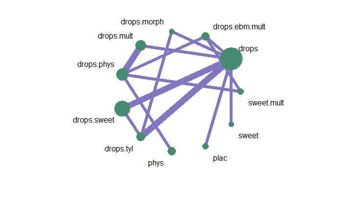

```r
momlinc_netgraph(pa_recov_int,pa_recov_int_char,"pa_reac",2,location = pa_recov_loc)
```

### Assessing missing means - Symmetry in medians?

```r
pa_recov = pa_recov %>% mutate(mean_imp = ifelse(mean == 888, median,mean)) %>% filter(mean_imp != 999) # creates a new variable where missing means are imputed from medians and excludes remaining 888s

pa_recov = data_study %>% select(study,speculum,scleral.dep,`Containment vs Swaddle`) %>% right_join(pa_recov, by = "study") # bring study level data over
```

### Placebo response graphs

```
'.\figs\primary outcome\pain scales recovery' already exists
```

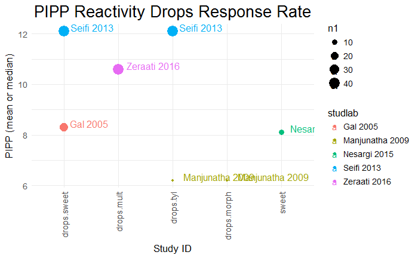

```r
plac_resp_graph(data = pa_recov_contrast, ref = "drops",filter = "treat1",facet = FALSE, location = pa_recov_loc,
               x = "treat2", y = "mean1", type = "scat", fill = "studlab", size = "n1", outcome = "pa_recov")
```